# Decsribing a graph

- Drastically/Dramatically/steeply
- Free Fall/ Plummet/ Plunge
- Fall/rise/increase/decrease/
- Flatten/Level off/ stay constant/
- Steadily rise/decline
- Show a decline/rise, experience a rise/fall
- Illustrate/Show/Depict/Portray/Delineate
- It plummeted to all time low/It bottomed out.
- Ballparked figure
- Approximately/ Or so
- Almost/nearly

### *Going Up*

```
rose
increased
went up
grew
```

### *Going Down*

```
decreased
fell
dropped
declined
plummeted
```

### *No Change*

```
stayed the same
remained constant
levelled off
stabilised
```

### *Up and Down*

```
fluctuated
zig-zagged
fluttered
undulated
```

### *Small Changes - Adjectives / Adverbs*

```
gently
gradually
slightly
steadily
```

### *Big Changes - Adverbs / Adjectives*

```
suddenly
sharply
dramatically
steeply
a lot
drastically
```

### *Low Points*

```
bottomed out
reached a low
```

### Barchart

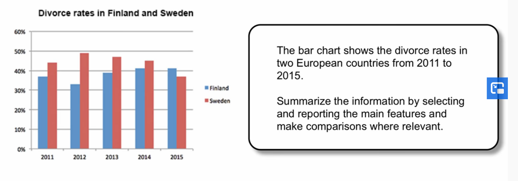

```python
from IPython.display import Image
from IPython.core.display import HTML
Image('barchart.png')
```

### Structure-1

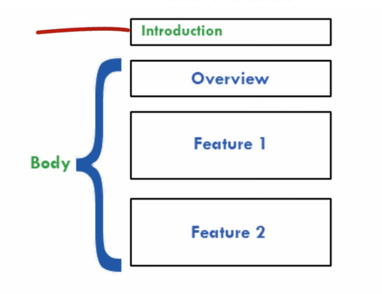

```python
from IPython.display import Image
from IPython.core.display import HTML
Image('str.png')
```

Introduction

- Describe what the graph is all about precisely
- Introduce the graph to readers in one or two sentences.
- Be specific about features in the introduction. In lieu of two European countries, mention the countries names

The bar chart provides information about the percentages of divorces in Finland and Sweden between 2011 and 2015.

- Never change the name of the graph (bar chart or line graph or ...)
- Shows = provides information about = represents = illustrates
- rates = percentages

Overview

- Describe some general trends and features of the graph
- Identify and Mention 2 to four key features.
- Never write numbers, percentages, or dates in the overview
- It should contain only the general informaiton
- Always start the overview paragraph with the word "Overall"

Key features

- Finland rate generally goes up higher
- Finland rate has some fluctuations
- Sweden rate generally goes down
- Sweden rate has some fluctuations
- At the beginning, Finland's rate is smaller
- At the end, Finland's rate is higher than that of Sweden

Overall, Sweden experienced a downward trend, while Finland showed an upward trend throughout the period. Both countries' rates had fluctuations. Although Finland initially had a lower rate, it outraced Sweden at the end of the period.

- Overall begins the overview paragraph
- while contrasts the opposite trends
- Although used to compare the trend of the two countries

Features

- Write about the specific features of the graph
- Group each features into separate paragraph to maintain cohesion and coherence.
- Two coutries = two features = two paragraphs

Sweden's divorce rate was about 45% in 2011, being higher than Finland's rate by approximately 8%. Then, it rose to almost fifty percent in 2012. However, the figure showed decrese to about 47% in 2013, and continued to decline steadily to the end of the period, reaching about 45% in 2014 and hitting a low-point of about 37% in 2015.

Percentages of divorces in Finland was less than 40% in 2011, and it decresed in 2012, when about one third of marriages in Finland ended with a divorce (as opposed to almost a half in Sweden). However, the figure experienced a steady growth during the next two years. It rose to approximately 39% in 2013, and then increased by about 3% in 2014, and remained steady for the next year, outracing the rate of Sweden.